# Technology mediation in child sexual exploitation and abuse in Africa and Asia

Disclosure descriptives script

Author

Ghai et al.

## Disclosure of Technology-facilitated CSEA

### Analysis Overview

We examined disclosure patterns and barriers following technology-facilitated CSEA through three sets of analyses.

**1. Disclosure Patterns**: We examined who children told about their experiences and whether they disclosed at all. We show a) non-mutually exclusive disclosure rates to different channels (police, helpline, social worker, teacher, friend, sibling, mother, father, other trusted adults), b) Mutually exclusive disclosure rates: no disclosure, informal channels only (family/friends), formal channels only (authorities), or both and c) a heatmap showing disclosure rates for nine CSEA experience types across all channels.

**2. Barriers to Disclosure**: Among children who did not disclose, we analyzed self-reported barriers, including overall prevalence: weighted proportions and 95% confidence intervals for 13 barriers using Wilson score intervals. We produce a two-panel figure showing both overall barriers with confidence intervals, and (b) barrier by CSEA type.

**3. Barrier Overlap**: We conducted co-occurrence analysis among non-disclosed incidents to examine whether barriers cluster or operate independently, including a) Distribution of barrier multiplicity (how many barriers per incident) and b) Full 13×13 co-occurrence matrix heatmap (diagonal = individual prevalence, off-diagonal = joint occurrence)

## Setup

```r
## load packages
library(tidyverse)
library(survey)
library(srvyr)
library(scales)
library(gtsummary)
library(kableExtra)
library(patchwork)
library(flextable)
library(viridis)
library(officer)
```

We select only the relevant variables for disclosure analyses

```r
# pull out disclosure variables
d_disclose <- d_victim %>%
  select(
    CBU_ID,
    COUNTRY,
    wgt_scaled,
    sex,
    age,
    victim,
    # all the disclose/abuse variables
    starts_with("toldnoone_"),
    starts_with("abuse_"),
    starts_with("police_"),
    starts_with("helpline_"),
    starts_with("teacher_"),
    starts_with("sworker_"),
    starts_with("friend_"),
    starts_with("sibling_"),
    starts_with("father_"),
    starts_with("mother_"),
    starts_with("other_"),
    starts_with("othera_"),
    starts_with("otheropen_"),
    starts_with("rdontknow_"),
    starts_with("rprefer_"),
    ## barriers
    contains("unable_"),
    contains("ashamed_"),
    contains("disbelief_"),
    contains("trouble_"),
    contains("troublefam_"),
    contains("myfault_"),
    contains("notserious_"),
    contains("knowledge_"),
    contains("troubleother_"),
    contains("noaction_"),
    contains("friendsdis_"),
    contains("parentsdis_"),
    contains("noconfidential_"),
    contains("barrierso_")
  )
# names(d_disclose)
```

## Define labels

```r
# CSEA type mappings (used throughout)
csea_type_labels <- c(
  "a" = "Unwanted sexual comments",
  "b" = "Sent unwanted sexual images",
  "c" = "Asked to talk about sex/acts",
  "d" = "Asked to do something sexual",
  "e" = "Asked for intimate photos/videos",
  "f" = "Offered money/gifts for images",
  "g" = "Offered money/gifts for in-person acts",
  "h" = "Shared sexual images without consent",
  "i" = "Threatened/blackmailed for sex"
)

# disclosure channel labels
channel_labels <- c(
  "police"    = "Police",
  "helpline"  = "Helpline",
  "sworker"   = "Social Worker",
  "friend"    = "Friend",
  "teacher"   = "Teacher",
  "mother"    = "Mother",
  "father"    = "Father",
  "sibling"   = "Sibling",
  "other"     = "Other",
  "othera"    = "Other Adults",
  "toldnoone" = "Did not disclose"
)

# barrier name prefixes (variable stems)
barrier_prefixes <- c(
  "unable", "ashamed", "disbelief", "trouble", "myfault",
  "notserious", "troubleother", "troublefam", "noaction",
  "knowledge", "friendsdis", "parentsdis", "noconfidential"
)

# functions that need barrier_list
barrier_list <- paste0(barrier_prefixes, "_")

# barrier labels - full descriptions
barrier_labels <- c(
  "unable"        = "Did not know where to go/who to tell",
  "ashamed"       = "Embarrassed/ashamed/too difficult",
  "disbelief"     = "Thought no one would believe me",
  "trouble"       = "Worried I would get in trouble",
  "myfault"       = "Felt I did something wrong",
  "notserious"    = "Did not think it was serious enough",
  "troubleother"  = "Did not want perpetrator in trouble",
  "troublefam"    = "Feared trouble for me/family",
  "noaction"      = "Did not think anything would be done",
  "knowledge"     = "Did not know you could report",
  "friendsdis"    = "Friends discouraged reporting",
  "parentsdis"    = "Parents discouraged reporting",
  "noconfidential"= "Feared lack of confidentiality"
)

# short barrier labels for visualizations
short_labels <- c(
  "unable"        = "Don't know",
  "ashamed"       = "Embarrassed/\nashamed",
  "disbelief"     = "Won't\nbelieve me",
  "trouble"       = "Get in\ntrouble",
  "myfault"       = "My fault",
  "notserious"    = "Not serious",
  "troubleother"  = "Perp in\ntrouble",
  "troublefam"    = "Family\ntrouble",
  "noaction"      = "Nothing\ndone",
  "knowledge"     = "Didn't know\ncould report",
  "friendsdis"    = "Friends\ndiscouraged",
  "parentsdis"    = "Parents\ndiscouraged",
  "noconfidential"= "No\nconfidential"
)

# channel phrases for the text summary (overall_channels)
channel_phrase <- c(
  toldnoone = "did not disclose",
  police    = "told police",
  helpline  = "contacted helpline",
  sworker   = "told social worker",
  friend    = "told friends",
  teacher   = "told teachers",
  mother    = "told mothers",
  father    = "told fathers",
  sibling   = "told siblings",
  othera    = "told other adults",
  other     = "other channels"
)

# used throughout code
label_csea_type <- function(x) unname(csea_type_labels[x])
label_channel   <- function(x) unname(channel_labels[x])
label_barrier   <- function(x) unname(barrier_labels[x])
label_barrier_short <- function(x) unname(short_labels[x])
```

# Disclosure Patterns Analysis

## Data Wrangling

To examine patterns of disclosure following technology-facilitated CSEA, we first derived a disclosure dataset from the main CSEA dataset. This involved aggregating responses across the nine types of technology-facilitated CSEA (labeled abuse_a to abuse_i) and identifying whether children disclosed any of these experiences to various sources.We defined a function to generate a binary disclosure indicator for each reporting channel (e.g., police, sibling, helpline). This indicator captures whether a child reported any of the nine types of CSEA to that particular channel.

To explore how the nature of the disclosure may be associated with disclosure, we constructed three summary variables based on who the child disclosed:

- Told all (any disclosures): A binary variable coded as 1 if the child reported disclosing any form of technology-facilitated CSEA to at least one of the following sources: (1. Father, step/foster father, or male caregiver/guardian; 2. Mother, step/foster mother, or female caregiver/guardian; 3. Brother or sister; 4. Friend; 5. Teacher or educator; 6. Other adults I know and trust, 7. Social worker; 8. Helpline; 9. Police; 10. Other).

Children who selected only “I didn’t tell anyone,” “Prefer not to say,” or “Don’t know” were excluded from the “told all” category.

- Told informal channel: A binary variable indicating disclosure to non-authority figures, such as parents, siblings, or friends.
- Told formal channel: A binary variable indicating disclosure to authority figures, including teachers, helplines, social workers, or police.

This creates non-mutually exclusive indicators, allowing us to capture the full complexity of disclosure patterns where children may tell multiple people.

```r
disclosure_data <- function(data) {

  # filter victims only
  victims <- data %>% filter(victim == 1)

  # disclosure channel names
  channels <- c("toldnoone", "police", "helpline", "teacher", "sworker",
                "friend", "sibling", "father", "mother", "other", "othera")

  # function to check if disclosed any abuse type to this channel
  check_channel <- function(prefix, data) {
    # abuse types are a-i
    cols <- paste0(prefix, "_", letters[1:9])
    rowSums(data[cols], na.rm = TRUE) > 0
  }

  # apply to each channel
  for (ch in channels) {
    victims[[ch]] <- check_channel(ch, victims)
  }

  ## create disclosure categories
  victims %>%
    mutate(
      # any disclosure?
      toldall = police | helpline | teacher | sworker | friend |
                 sibling | father | mother | other | othera,
      # formal vs informal
      toldformal = police | helpline | teacher | sworker,
      toldinformal = friend | sibling | father | mother | other | othera,

      # make mutually exclusive
      no_disclosure = !toldall,
      informal_only = toldinformal & !toldformal,
      formal_only = toldformal & !toldinformal,
      both_channels = toldinformal & toldformal,

      # now factor
      disclosure_type = case_when(
        both_channels ~ "Both",
        informal_only ~ "Informal only",
        formal_only ~ "Formal only",
        no_disclosure ~ "None"
      ),
      disclosure_type = factor(disclosure_type,
                              levels = c("None", "Informal only", "Formal only", "Both"))
    )
}

d_report <- disclosure_data(d_disclose)
```

## 1. Overall Disclosure Rates (Non-Mutually Exclusive)

We first set up the survey design object to properly account for sampling weights in all subsequent analyses. This table shows **non-exclusive** disclosure rates - children who disclosed to multiple channels appear in multiple rows.

```r
# survey design
svy_victims <- d_report %>%
  filter(victim == 1) %>%
  as_survey_design(weights = wgt_scaled)
```

```r
# overall channel function
calc_channel <- function(var) {
  svy_victims %>%
    summarise(
      p             = survey_mean(as.numeric(.data[[var]] == 1), vartype = "ci", na.rm = TRUE),
      Nw_sel        = survey_total(as.numeric(.data[[var]] == 1), na.rm = TRUE),
      Nw_denom      = survey_total(as.numeric(!is.na(.data[[var]])), na.rm = TRUE),
      n_select_unw  = unweighted(sum(.data[[var]] == 1, na.rm = TRUE)),
      n_nonmiss_unw = unweighted(sum(!is.na(.data[[var]])))
    ) %>%
    mutate(
      COUNTRY  = "Overall",
      channel  = var,
      pct      = p * 100,
      pct_low  = p_low * 100,
      pct_upp  = p_upp * 100
    ) %>%
    select(COUNTRY, channel, pct, pct_low, pct_upp,
           n_select_unw, n_nonmiss_unw, Nw_sel, Nw_denom)
}

# by country channel function
calc_channel_country <- function(var) {
  svy_victims %>%
    group_by(COUNTRY) %>%
    summarise(
      p             = survey_mean(as.numeric(.data[[var]] == 1), vartype = "ci", na.rm = TRUE),
      Nw_sel        = survey_total(as.numeric(.data[[var]] == 1), na.rm = TRUE),
      Nw_denom      = survey_total(as.numeric(!is.na(.data[[var]])), na.rm = TRUE),
      n_select_unw  = unweighted(sum(.data[[var]] == 1, na.rm = TRUE)),
      n_nonmiss_unw = unweighted(sum(!is.na(.data[[var]])))
    ) %>%
    mutate(
      channel  = var,
      pct      = p * 100,
      pct_low  = p_low * 100,
      pct_upp  = p_upp * 100
    ) %>%
    select(COUNTRY, channel, pct, pct_low, pct_upp,
           n_select_unw, n_nonmiss_unw, Nw_sel, Nw_denom)
}

# run both and bind
table_overall <- map_dfr(channels, calc_channel)
table_country <- map_dfr(channels, calc_channel_country) %>%
  filter(!is.na(COUNTRY))

# build final table
disclosure_channel_table <- bind_rows(table_overall, table_country) %>%
  filter(!is.na(COUNTRY)) %>%
  mutate(
    Channel = dplyr::recode(channel,
      "police"    = "Police",
      "helpline"  = "Helpline",
      "sworker"   = "Social Worker",
      "friend"    = "Friend",
      "teacher"   = "Teacher",
      "mother"    = "Mother",
      "father"    = "Father",
      "sibling"   = "Sibling",
      "other"     = "Other",
      "othera"    = "Other Adults",
      "toldnoone" = "Did not disclose"
    ),
    `n (unweighted)` = n_select_unw,
    `N (unweighted)` = n_nonmiss_unw,
    `n (weighted)`   = round(Nw_sel, 0),
    `N (weighted)`   = round(Nw_denom, 0),
    `Prevalence (%)` = round(pct, 1),
    `Lower CI`       = round(pct_low, 1),
    `Upper CI`       = round(pct_upp, 1)
  ) %>%
  select(
    Country          = COUNTRY,
    Channel,
    `n (unweighted)`, `N (unweighted)`,
    `n (weighted)`,   `N (weighted)`,
    `Prevalence (%)`, `Lower CI`, `Upper CI`
  ) %>%
  arrange(Channel, desc(Country == "Overall"), Country) %>%
  as.data.frame()
```

```r
disclosure_channel_table %>%
  kable(
    booktabs  = TRUE,
    longtable = TRUE,
    caption   = "Survey-weighted disclosure rates by channel and country (2020–2021)",
    align     = c("l", "l", rep("r", 7))
  ) %>%
  kable_styling(
    latex_options = c("striped", "repeat_header", "scale_down"),
    full_width    = FALSE,
    font_size     = 9
  ) %>%
  collapse_rows(columns = 1, valign = "top")
```

Survey-weighted disclosure rates by channel and country (2020–2021)

| Country | Channel | n (unweighted) | N (unweighted) | n (weighted) | N (weighted) | Prevalence (%) | Lower CI | Upper CI |
| --- | --- | --- | --- | --- | --- | --- | --- | --- |
| Overall | Did not disclose | 1080 | 2067 | 1034 | 2025 | 51.1 | 48.6 | 53.6 |
| Cambodia | Did not disclose | 74 | 137 | 78 | 145 | 53.8 | 44.8 | 62.8 |
| Ethiopia | Did not disclose | 101 | 195 | 96 | 186 | 51.5 | 42.9 | 60.0 |
| Indonesia | Did not disclose | 35 | 66 | 36 | 66 | 53.8 | 40.8 | 66.9 |
| Kenya | Did not disclose | 111 | 230 | 102 | 220 | 46.3 | 39.3 | 53.2 |
| Malaysia | Did not disclose | 62 | 109 | 56 | 102 | 54.9 | 44.0 | 65.8 |
| Mozambique | Did not disclose | 108 | 231 | 117 | 258 | 45.2 | 37.7 | 52.6 |
| Namibia | Did not disclose | 139 | 225 | 117 | 198 | 58.8 | 51.0 | 66.5 |
| Philippines | Did not disclose | 137 | 269 | 138 | 271 | 50.7 | 43.9 | 57.5 |
| Tanzania | Did not disclose | 47 | 88 | 38 | 77 | 48.9 | 37.3 | 60.4 |
| Thailand | Did not disclose | 93 | 157 | 97 | 164 | 59.1 | 50.8 | 67.5 |
| Uganda | Did not disclose | 148 | 311 | 130 | 281 | 46.3 | 39.9 | 52.8 |
| Vietnam | Did not disclose | 25 | 49 | 31 | 54 | 57.3 | 40.9 | 73.6 |
| Overall | Father | 384 | 2067 | 403 | 2025 | 19.9 | 17.9 | 21.9 |
| Cambodia | Father | 51 | 137 | 57 | 145 | 39.2 | 30.3 | 48.1 |
| Ethiopia | Father | 33 | 195 | 37 | 186 | 19.8 | 12.7 | 27.0 |
| Indonesia | Father | 8 | 66 | 6 | 66 | 8.6 | 2.2 | 15.0 |
| Kenya | Father | 38 | 230 | 38 | 220 | 17.3 | 12.0 | 22.6 |
| Malaysia | Father | 20 | 109 | 22 | 102 | 21.2 | 12.0 | 30.5 |
| Mozambique | Father | 39 | 231 | 53 | 258 | 20.4 | 13.8 | 26.9 |
| Namibia | Father | 44 | 225 | 41 | 198 | 20.6 | 14.5 | 26.8 |
| Philippines | Father | 37 | 269 | 42 | 271 | 15.6 | 10.4 | 20.8 |
| Tanzania | Father | 16 | 88 | 15 | 77 | 19.7 | 10.6 | 28.8 |
| Thailand | Father | 51 | 157 | 51 | 164 | 31.0 | 23.3 | 38.8 |
| Uganda | Father | 45 | 311 | 41 | 281 | 14.5 | 10.0 | 19.0 |
| Vietnam | Father | 2 | 49 | 1 | 54 | 1.9 | -0.8 | 4.7 |
| Overall | Friend | 956 | 2067 | 923 | 2025 | 45.6 | 43.1 | 48.1 |
| Cambodia | Friend | 53 | 137 | 51 | 145 | 35.1 | 26.8 | 43.5 |
| Ethiopia | Friend | 94 | 195 | 84 | 186 | 45.0 | 36.5 | 53.4 |
| Indonesia | Friend | 29 | 66 | 30 | 66 | 45.1 | 32.1 | 58.2 |

[output cut: 113 more lines]

## 2. Mutually Exclusive Disclosure Categories

We categorize each victim into one mutually exclusive disclosure category to understand overall disclosure behavior patterns.While the previous analysis showed overlap, this classification helps us understand the primary disclosure pathway for each victim. Below are categories:

1. None: Told no one
2. Informal only: Told family/friends but not authorities
3. Formal only: Told authorities but not family/friends
4. Both: Told both informal and formal channels

```r
# survey design object
svy <- d_report %>% as_survey_design(weights = wgt_scaled)

# calc patterns by country
m_disclosure <- svy %>%
  group_by(COUNTRY) %>%
  summarise(
    None = survey_mean(no_disclosure, vartype = NULL),
    `Informal only` = survey_mean(informal_only, vartype = NULL),
    `Formal only` = survey_mean(formal_only, vartype = NULL),
    Both = survey_mean(both_channels, vartype = NULL)
  ) %>%
  pivot_longer(-COUNTRY, names_to = "Category", values_to = "p") %>%
  mutate(Category = factor(Category,
                           levels = c("None", "Informal only", "Formal only", "Both")))

# get any disclosure rates
any_d <- svy %>%
  group_by(COUNTRY) %>%
  summarise(any = survey_mean(toldall, vartype = NULL)) %>%
  mutate(any_lab = percent(any, accuracy = 1))

# order countries by Both category for vis
country_order <- m_disclosure %>%
  filter(Category == "Both") %>%
  arrange(p) %>%
  pull(COUNTRY)

m_disclosure <- m_disclosure %>%
  mutate(
    COUNTRY = factor(COUNTRY, levels = country_order),
    pct_lab = percent(p, accuracy = 0.1),
    show_lab = p >= 0.01
  )

any_d <- any_d %>%
  mutate(COUNTRY = factor(COUNTRY, levels = country_order))
```

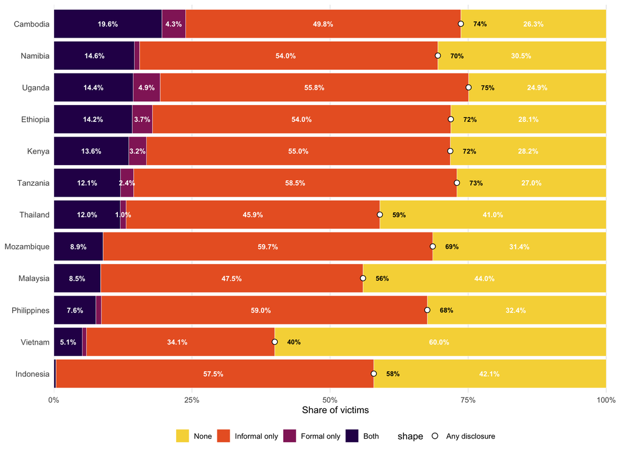

Mutually exclusive disclosure patterns by country

```r
# stacked bar chart
disclosure_mutualex <- ggplot(m_disclosure, aes(x = COUNTRY, y = p, fill = Category)) +
  geom_col(width = 0.9, position = "fill", color = "white", linewidth = 0.2) +
  geom_text(
    data = filter(m_disclosure, show_lab),
    aes(label = pct_lab),
    position = position_fill(vjust = 0.5),
    size = 3.2, fontface = "bold", color = "white"
  ) +
  scale_fill_viridis_d(option = "inferno", begin = 0.15, end = 0.9, direction = -1) +
  scale_y_continuous(labels = label_percent(), limits = c(0, 1),
                     expand = expansion(mult = c(0, 0.02))) +
  labs(x = NULL, y = "Share of victims", fill = NULL) +
  coord_flip() +
  theme_minimal(base_size = 12) +
  theme(
    legend.position = "bottom",
    panel.grid.major.y = element_blank(),
    panel.grid.minor = element_blank(),
    axis.text.y = element_text(size = 10),
    plot.title = element_text(face = "bold")
  ) +
  geom_point(
    data = any_d,
    aes(x = COUNTRY, y = any, shape = "Any disclosure"),
    inherit.aes = FALSE,
    size = 2.8, stroke = 0.6, color = "black", fill = "white"
  ) +
  geom_text(
    data = any_d,
    aes(x = COUNTRY, y = pmin(any + 0.035, 0.98), label = any_lab),
    inherit.aes = FALSE,
    size = 3.0, fontface = "bold", color = "black"
  ) +
  scale_shape_manual(values = c("Any disclosure" = 21)) +
  guides(
    fill = guide_legend(order = 1),
    shape = guide_legend(order = 2,
                        override.aes = list(color = "black", fill = "white", size = 3))
  )

disclosure_mutualex
```

```r
ggsave("figure3_disclosure.pdf",
       disclosure_mutualex,
       width = 11,
       height = 8,
       dpi = 600
       )
```

## 3. Disclosure: CSEA Type by Channel

Now we transform data from person-level to incident-level, where each row represents one child experiencing one specific type of CSEA.

```r
# exact channel stems - order matters to avoid other/othera ambiguity
channel_stems <- c("police","helpline","sworker","friend","teacher",
                   "mother","father","sibling","othera","other")

# survey object
svy_heatmap <- svydesign(id = ~1, weights = ~wgt_scaled, data = d_victim)

# build exact column list manually - no regex ambiguity
heatmap_cols <- outer(channel_stems, paste0("_", letters[1:9]), paste0) %>%
  as.vector() %>%
  intersect(names(svy_heatmap$variables))

# reshape to long - split from RIGHT to avoid other/othera confusion
long_disc <- svy_heatmap$variables %>%
  select(wgt_scaled, all_of(heatmap_cols)) %>%
  pivot_longer(
    cols      = all_of(heatmap_cols),
    names_to  = "varname",
    values_to = "disclosed"
  ) %>%
  mutate(
    type    = str_extract(varname, "[a-i]$"),
    channel = str_remove(varname, "_[a-i]$")
  )

# weighted rates
svy_long <- svydesign(id = ~1, weights = ~wgt_scaled, data = long_disc)
rates <- svyby(~disclosed, ~channel + type, svy_long, svymean, na.rm = TRUE)

# apply labels ONCE here
rates <- rates %>%
  mutate(
    type    = label_csea_type(type),
    channel = label_channel(channel)
  )

# kable table
rates_csea <- rates %>%
  mutate(pct = sprintf("%.1f%%", disclosed * 100)) %>%
  select(type, channel, pct) %>%
  pivot_wider(names_from = channel, values_from = pct) %>%
  rename(`CSEA Type` = type)

rates_csea %>%
  kable(
    booktabs = TRUE,
    caption  = "Survey-weighted percentages of child victims who disclosed
                their experience by CSEA type and channel (2020–2021).
                Denominator for each cell is children who experienced that
                specific CSEA type. Percentages are non-additive as children
                could disclose to multiple channels."
  ) %>%
  kable_styling(latex_options = c("striped", "scale_down"), font_size = 9)
```

Survey-weighted percentages of child victims who disclosed their experience by CSEA type and channel (2020–2021). Denominator for each cell is children who experienced that specific CSEA type. Percentages are non-additive as children could disclose to multiple channels.

| CSEA Type | Father | Friend | Helpline | Mother | Other | Other Adults | Police | Sibling | Social Worker | Teacher |
| --- | --- | --- | --- | --- | --- | --- | --- | --- | --- | --- |
| Unwanted sexual comments | 8.6% | 29.6% | 0.6% | 11.1% | 1.0% | 2.7% | 1.2% | 12.4% | 0.9% | 4.1% |
| Sent unwanted sexual images | 9.7% | 31.9% | 0.6% | 9.9% | 0.4% | 2.0% | 1.2% | 13.7% | 1.0% | 3.9% |
| Asked to talk about sex/acts | 9.9% | 29.3% | 0.9% | 10.5% | 0.5% | 2.0% | 2.1% | 15.4% | 0.9% | 4.9% |
| Asked to do something sexual | 9.0% | 30.9% | 1.1% | 12.2% | 0.1% | 3.0% | 1.4% | 16.0% | 1.1% | 4.7% |
| Asked for intimate photos/videos | 11.6% | 29.2% | 1.2% | 12.6% | 0.3% | 2.0% | 2.3% | 16.3% | 1.2% | 2.8% |
| Offered money/gifts for images | 14.1% | 31.3% | 1.4% | 15.6% | 0.1% | 2.0% | 1.7% | 16.7% | 1.0% | 4.5% |
| Offered money/gifts for in-person acts | 12.5% | 30.6% | 1.2% | 14.8% | 0.3% | 4.6% | 1.5% | 18.4% | 1.3% | 4.3% |
| Shared sexual images without consent | 10.2% | 30.1% | 2.0% | 13.3% | 0.4% | 3.1% | 2.1% | 16.9% | 1.6% | 4.4% |
| Threatened/blackmailed for sex | 12.9% | 32.3% | 1.4% | 15.1% | 0.3% | 4.6% | 2.2% | 19.2% | 1.4% | 4.9% |

We visualise disclosure patterns across all CSEA types and channels in a single comprehensive heatmap.This visual helps us quickly identify which CSEA types have highest/lowest disclosure rates and which channels are most/least used for different abuse types.

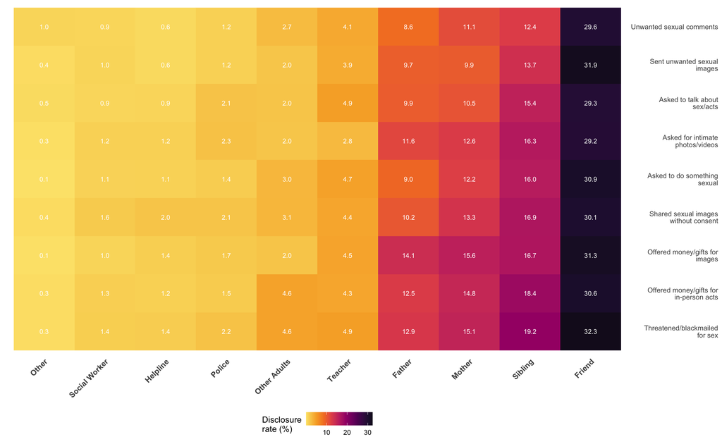

Non-exclusive disclosure rates by CSEA type and channel

```r
# order channels lowest to highest (so highest is rightmost on x-axis)
chan_order <- rates %>%
  group_by(channel) %>%
  summarise(avg = mean(disclosed, na.rm = TRUE)) %>%
  arrange(avg) %>%
  pull(channel)

# order types highest to lowest
type_order <- rates %>%
  group_by(type) %>%
  summarise(avg = mean(disclosed, na.rm = TRUE)) %>%
  arrange(desc(avg)) %>%
  pull(type)

# wrap labels
rates_plot <- rates %>%
  mutate(
    type    = str_wrap(type, width = 25),
    type    = factor(type, levels = str_wrap(type_order, width = 25)),
    channel = factor(channel, levels = chan_order)
  )

heatmap_disclosure <- ggplot(rates_plot,
                             aes(x = channel, y = type, fill = disclosed * 100)) +
  geom_raster() +
  geom_text(
    aes(label = sprintf("%.1f", disclosed * 100)),
    size = 3, color = "white"
  ) +
  scale_y_discrete(position = "right") +
  colorspace::scale_fill_continuous_sequential(
    palette = "Inferno",
    begin   = 0.06,
    end     = 0.95,
    name    = "Disclosure\nrate (%)"
  ) +
  labs(
    x       = NULL,
    y       = NULL
  ) +
  theme_minimal() +
  theme(
    axis.text.x     = element_text(face = "bold", angle = 45, hjust = 1, size = 10),
    axis.text.y     = element_text(size = 9, lineheight = 0.85),
    legend.position = "bottom",
    panel.grid      = element_blank(),
    plot.margin     = margin(5, 5, 5, 10),
    plot.caption    = element_text(size = 7, hjust = 0)
  )

heatmap_disclosure
```

```r
ggsave("disclosure_heatmap.pdf",
       heatmap_disclosure,
       width  = 13,
       height = 8,
       units  = "in",
       dpi    = 600)
```

# Barriers to Disclosure Analysis

## 1. Overall barrier prevalence

We calculated confidence intervals using Wilson score intervals because Wilson intervals perform better when proportions approach 0 or 1 and with small sample sizes, conditions present in our stratified analyses. We choose Wilson CI instead of standard Wald CI because: 1) Better coverage near 0 or 1 (common in our stratified analyses) 2) Never produces CI outside [0,1] bounds 3) Better for small samples (some CSEA types are rare)

```r
# function to reshape barriers
long_barriers <- function(data, barrier_list) {
  prefix_rx <- paste0("^(", paste(barrier_list, collapse = "|"), ")[a-i]$")
  bar_cols  <- grep(prefix_rx, names(data), value = TRUE)

  # pull toldnoone columns once for the join
  toldnoone_cols <- grep("^toldnoone_[a-i]$", names(data), value = TRUE)

  toldnoone_long <- data %>%
    mutate(rid = dplyr::row_number()) %>%
    select(rid, dplyr::all_of(toldnoone_cols)) %>%
    pivot_longer(
      dplyr::all_of(toldnoone_cols),
      names_to     = "mask_col",
      values_to    = "mask_val",
      names_prefix = "toldnoone_"
    ) %>%
    rename(type_letter = mask_col)

  data %>%
    mutate(rid = dplyr::row_number()) %>%
    select(rid, wgt_scaled, dplyr::all_of(bar_cols)) %>%
    pivot_longer(
      dplyr::all_of(bar_cols),
      names_to  = "name",
      values_to = "value_raw"
    ) %>%
    mutate(
      barrier_key = sub("_[a-i]$", "", name),
      type_letter = stringr::str_extract(name, "[a-i]$"),
      value       = as.numeric(value_raw),
      value       = dplyr::if_else(value > 1, 1, value, missing = value)
    ) %>%
    # join mask by rid + type_letter
    left_join(toldnoone_long, by = c("rid", "type_letter")) %>%
    filter(mask_val == 1, !is.na(value)) %>%
    mutate(
      barrier   = label_barrier(barrier_key),
      csea_type = label_csea_type(type_letter)
    ) %>%
    dplyr::select(rid, wgt_scaled, barrier, csea_type, value)
}

# calculate Wilson CI and barrier estimates
estimate_barriers <- function(long_df) {

  wilson_ci <- function(x, w, conf.level = 0.95) {
    # missing values
    ok <- !is.na(x) & !is.na(w)
    x  <- x[ok]
    w  <- w[ok]

    # minimum sample for stability
    if (length(x) < 5) {
      return(list(p = NA, ll = NA, ul = NA, n = length(x), n_eff = 0))
    }

    # weighted proportion
    p     <- stats::weighted.mean(x, w)
    n_eff <- sum(w)^2 / sum(w^2)

    # wilson score interval
    z <- stats::qnorm(1 - (1 - conf.level) / 2)

    # wilson interval formula
    denominator <- 1 + z^2 / n_eff
    center      <- (p + z^2 / (2 * n_eff)) / denominator
    margin      <- z * sqrt(p * (1 - p) / n_eff + z^2 / (4 * n_eff^2)) / denominator

    # gives us bounded estimates
    list(
      p    = p,
      ll   = max(0, center - margin),
      ul   = min(1, center + margin),
      n    = length(x),
      n_eff = round(n_eff, 1)
    )
  }

  # overall estimates
  overall_df <- long_df %>%
    group_by(barrier) %>%
    summarise(
      ci_result = list(wilson_ci(value, wgt_scaled)),
      .groups   = "drop"
    ) %>%
    unnest_wider(ci_result)

  # by-type estimates
  type_df <- long_df %>%
    group_by(barrier, csea_type) %>%
    summarise(
      ci_result  = list(wilson_ci(value, wgt_scaled)),
      n_positive = sum(value == 1, na.rm = TRUE),
      .groups    = "drop"
    ) %>%
    unnest_wider(ci_result) %>%
    mutate(

      # reliability flags
      reliable  = n >= 10 & n_positive >= 3 & !is.na(ll) & !is.na(ul),
      precision = ul - ll,
      wide_ci   = precision > 0.20,
      ci_status = dplyr::case_when(
        !reliable ~ "insufficient_n",
        wide_ci   ~ "imprecise",
        TRUE      ~ "reliable"
      ),
      ci_status = factor(ci_status, levels = c("reliable", "imprecise", "insufficient_n"))
    )

  list(overall_df = overall_df, type_df = type_df)
}
```

Calculate barrier prevalence with Wilson score CIs

```r
# now we run functions with Wilson
long_df <- long_barriers(d_victim, barrier_list)
ests_wilson <- estimate_barriers(long_df)

# plot limits
max_overall <- max(ests_wilson$overall_df$ul, na.rm = TRUE)
max_types <- max(ests_wilson$type_df$p, na.rm = TRUE)
max_val <- max(max_overall, max_types, na.rm = TRUE)
plot_limit <- max(0.60, ceiling(max_val * 20) / 20)
```

We create two barriers functions to plot pooled barriers as well as by CSEA subtype

```r
# panel a: overall barriers
plot_overall <- function(overall_df, lim) {
  overall_df <- overall_df %>%
    arrange(p) %>%
    mutate(barrier = fct_inorder(barrier))

  ggplot(overall_df, aes(x = p, y = barrier)) +
    geom_segment(aes(x = ll, xend = ul, yend = barrier),
                 linewidth = 0.5, color = "grey30") +
    geom_point(size = 2.5, shape = 18, color = "black") +
    scale_x_continuous(
      labels = percent_format(accuracy = 1),
      limits = c(0, lim),
      breaks = seq(0, lim, by = 0.10),
      expand = expansion(mult = c(0.01, 0.04))
    ) +
    labs(
      x = "Weighted proportion (%)",
      y = NULL,
      title = "Overall share of non-disclosed instances of each barrier"
    ) +
    theme_minimal(base_size = 8, base_family = "sans") +
  theme(
    axis.text.y  = element_text(size = 5, family = "sans"),
    axis.text.x  = element_text(size = 5, family = "sans"),
    axis.title.x = element_text(size = 7, family = "sans", margin = margin(t = 3)),
    plot.title   = element_text(size = 8, face = "bold", family = "sans"),
      panel.grid.minor = element_blank(),
      panel.grid.major.y = element_blank(),
      panel.grid.major.x = element_line(color = "grey85", linewidth = 0.25),
      panel.border = element_rect(color = "black", fill = NA, linewidth = 0.5),
      plot.margin = margin(3, 3, 3, 3)
    )
}
```

```r
# panel b: CSEA type
plot_by_type <- function(type_df, overall_df, lim) {
  barrier_order <- overall_df %>% arrange(p) %>% pull(barrier)

  plot_data <- type_df %>%
    mutate(
      barrier = factor(barrier, levels = barrier_order),
      csea_type = factor(csea_type)
    ) %>%
    filter(!is.na(p), !is.na(barrier))

  n_types <- n_distinct(plot_data$csea_type)
  colors <- viridis(n_types, option = "inferno", begin = 0.15, end = 0.90)

  ggplot(plot_data, aes(x = p, y = barrier, color = csea_type)) +
    geom_segment(aes(xend = 0, yend = barrier), linewidth = 0.5, alpha = 0.7) +
    geom_point(aes(shape = ci_status, size = ci_status, alpha = ci_status)) +
    scale_shape_manual(
      values = c("reliable" = 16, "imprecise" = 16, "insufficient_n" = 1),
      guide = "none"
    ) +
    scale_size_manual(
      values = c("reliable" = 1.8, "imprecise" = 1.6, "insufficient_n" = 1.4),
      guide = "none"
    ) +
    scale_alpha_manual(
      values = c("reliable" = 1.0, "imprecise" = 0.7, "insufficient_n" = 0.5),
      guide = "none"
    ) +
    scale_x_continuous(
      labels = percent_format(accuracy = 1),
      limits = c(0, lim),
      breaks = seq(0, lim, by = 0.10),
      expand = expansion(mult = c(0.01, 0.05))
    ) +
    scale_color_manual(values = colors, guide = "none") +
    facet_wrap(~csea_type, ncol = 3) +
    labs(
      x = "Weighted proportion (%)",
      y = NULL,
      title = "Barriers by CSEA type (share of non-disclosed instances)"
    ) +
    theme_minimal(base_size = 7, base_family = "sans") +
  theme(
    strip.text   = element_text(color = "white", face = "bold",
                                size = 6.5, family = "sans"),
    axis.text.y  = element_text(size = 5, family = "sans"),
    axis.text.x  = element_text(size = 5, family = "sans"),
    axis.title.x = element_text(size = 6.5, family = "sans", margin = margin(t = 2)),
    plot.title   = element_text(size = 7, face = "bold", family = "sans"),
      strip.background = element_rect(fill = "grey20", color = "grey20"),
      panel.grid.minor = element_blank(),
      panel.grid.major.y = element_blank(),
      panel.grid.major.x = element_line(color = "grey85", linewidth = 0.25),
      panel.border = element_rect(color = "black", fill = NA, linewidth = 0.35),
      panel.spacing = unit(0.35, "lines"),
      plot.margin = margin(2, 2, 2, 2)
    )
}
```

## 2. Barriers to Disclosure (Figure 3)

We analysed barriers among children who did not disclose their technology-facilitated CSEA experiences (instance-level denominator). For each barrier we computed survey-weighted proportions with two-sided 95% Wilson score intervals, using an effective sample size to reflect weighting. Estimates based on <10 observations or <3 positive responses are reported without confidence intervals due to insufficient precision.

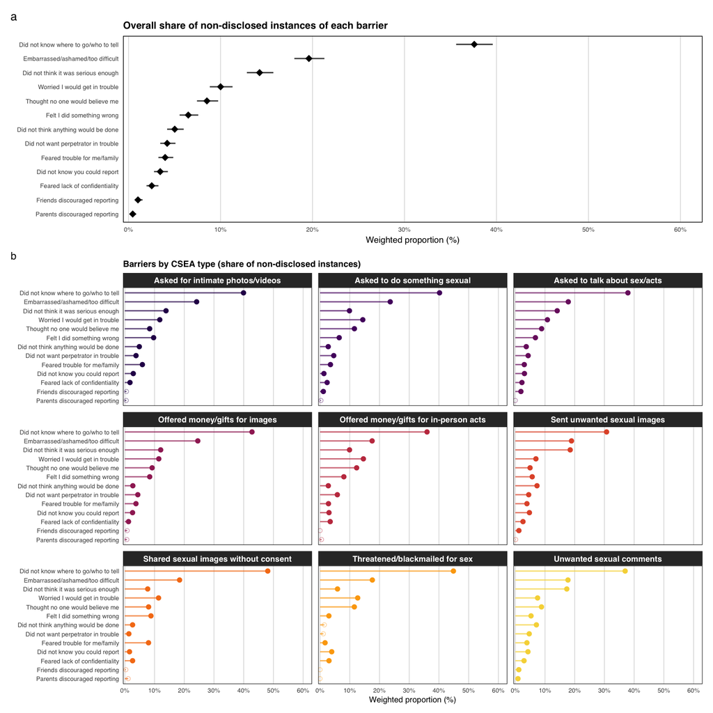

Barriers to seeking help after technology-facilitated CSEA

```r
# create combined figure
p_overall <- plot_overall(ests_wilson$overall_df, plot_limit)
p_types <- plot_by_type(ests_wilson$type_df, ests_wilson$overall_df, plot_limit)

barriers_figure <- p_overall / p_types +
  plot_layout(heights = c(0.32, 0.68)) +
  plot_annotation(tag_levels = "a")

barriers_figure
```

```r
# save as Fig 3
ggsave("figure_3.pdf",
       barriers_figure &
         theme(
          axis.title = element_text(size = 7, family = "sans"),
         axis.text  = element_text(size = 5, family = "sans"),
         strip.text = element_text(face = "bold", size = 5,
                                   colour = "white", family = "sans"),
       ),
       width  = 18,
       height = 17,
       units  = "cm",
       dpi    = 600,
       bg     = "white")
```

## 3. All Barriers Ranked Table

```r
barriers_ranked <- ests_wilson$overall_df %>%
  arrange(desc(p)) %>%
  mutate(
    Rank = row_number(),
    Barrier = barrier,
    `Prevalence (%)` = sprintf("%.1f", p * 100),
    `95% CI` = sprintf("[%.1f, %.1f]", ll * 100, ul * 100),
    `Sample Size` = n,
    `Effective N` = round(n_eff, 0)
  ) %>%
  select(Rank, Barrier, `Prevalence (%)`, `95% CI`, `Sample Size`, `Effective N`)

kable(barriers_ranked, align = c("c", "l", "r", "r", "r", "r"))
```

All barriers to disclosure ranked by prevalence

| Rank | Barrier | Prevalence (%) | 95% CI | Sample Size | Effective N |
| --- | --- | --- | --- | --- | --- |
| 1 | Did not know where to go/who to tell | 37.6 | [35.6, 39.6] | 2921 | 2269 |
| 2 | Embarrassed/ashamed/too difficult | 19.6 | [18.0, 21.3] | 2921 | 2269 |
| 3 | Did not think it was serious enough | 14.2 | [12.9, 15.7] | 2921 | 2269 |
| 4 | Worried I would get in trouble | 10.0 | [8.8, 11.3] | 2921 | 2269 |
| 5 | Thought no one would believe me | 8.5 | [7.4, 9.7] | 2921 | 2269 |
| 6 | Felt I did something wrong | 6.5 | [5.6, 7.6] | 2921 | 2269 |
| 7 | Did not think anything would be done | 5.0 | [4.2, 6.0] | 2921 | 2269 |
| 8 | Did not want perpetrator in trouble | 4.2 | [3.4, 5.1] | 2921 | 2269 |
| 9 | Feared trouble for me/family | 4.0 | [3.2, 4.9] | 2921 | 2269 |
| 10 | Did not know you could report | 3.4 | [2.8, 4.3] | 2921 | 2269 |
| 11 | Feared lack of confidentiality | 2.5 | [2.0, 3.2] | 2921 | 2269 |
| 12 | Friends discouraged reporting | 1.0 | [0.7, 1.5] | 2921 | 2269 |
| 13 | Parents discouraged reporting | 0.5 | [0.2, 0.8] | 2921 | 2269 |

## 4. Supplementary Table: Barriers by CSEA Type

```r
# function to create barriers table
barriers_table <- function(overall_df, type_df) {

  # format estimates
  format_compact <- function(p, ll, ul, reliable, wide_ci) {
    est <- sprintf("%.1f", p * 100)

    if (!reliable) {
      return(paste0(est, "†"))
    } else if (wide_ci) {
      ci <- sprintf("[%.1f,%.1f]‡", ll * 100, ul * 100)
      return(paste0(est, ci))
    } else {
      ci <- sprintf("[%.1f,%.1f]", ll * 100, ul * 100)
      return(paste0(est, ci))
    }
  }

  # overall
  overall_formatted <- overall_df %>%
    mutate(
      Overall = sprintf("%.1f [%.1f,%.1f]", p * 100, ll * 100, ul * 100)
    ) %>%
    select(barrier, Overall)

  # types
  type_formatted <- type_df %>%
    mutate(
      formatted = pmap_chr(
        list(p, ll, ul, reliable, wide_ci),
        format_compact
      )
    ) %>%
    select(barrier, csea_type, formatted) %>%
    pivot_wider(
      names_from = csea_type,
      values_from = formatted
    )

  # combine
  wide_table <- overall_formatted %>%
    left_join(type_formatted, by = "barrier") %>%
    left_join(overall_df %>% select(barrier, p), by = "barrier") %>%
    arrange(desc(p)) %>%
    select(-p)

  return(wide_table)
}

# create barriers table
barriers_compact <- barriers_table(
  ests_wilson$overall_df,
  ests_wilson$type_df
)

barriers_disclosure <- barriers_compact %>%
  flextable() %>%
  set_header_labels(barrier = "Barrier to Disclosure") %>%
  bold(part = "header") %>%
  width(j = 1, width = 2.2) %>%
  width(j = 2:ncol(barriers_compact), width = 1.1) %>%
  align(j = 2:ncol(barriers_compact), align = "center", part = "all") %>%
  align(j = 1, align = "left", part = "all") %>%
  fontsize(size = 8, part = "all") %>%
  fontsize(size = 9, part = "header") %>%
  border_outer(border = fp_border(width = 2)) %>%
  border_inner_h(border = fp_border(width = 0.5)) %>%
  border_inner_v(border = fp_border(width = 0.5)) %>%
  add_header_row(
    values = c("", "Overall", "CSEA Type"),
    colwidths = c(1, 1, ncol(barriers_compact) - 2)
  ) %>%
  merge_h(part = "header", i = 1) %>%
  add_footer_lines(
    values = c(
      "Estimate [Lower CI, Upper CI]. All values are percentages.",
      "† Insufficient sample size (n<10 or <3 events); confidence interval not shown.",
      "‡ Imprecise estimate (confidence interval width >20 percentage points).",
      "Confidence intervals calculated using Wilson score method, bounded at [0, 100]."
    )
  ) %>%
  fontsize(size = 7, part = "footer") %>%
  italic(part = "footer") %>%
  align(align = "left", part = "footer") %>%
  theme_booktabs() %>%
  autofit()

barriers_disclosure
```

| Barrier to Disclosure | Overall | CSEA Type Asked for intimate photos/videos | CSEA Type Asked to do something sexual | CSEA Type Asked to talk about sex/acts | CSEA Type Offered money/gifts for images | CSEA Type Offered money/gifts for in-person acts | CSEA Type Sent unwanted sexual images | CSEA Type Shared sexual images without consent | CSEA Type Threatened/blackmailed for sex | CSEA Type Unwanted sexual comments |
| --- | --- | --- | --- | --- | --- | --- | --- | --- | --- | --- |
| Did not know where to go/who to tell | 37.6 [35.6,39.6] | 39.9[33.3,47.0] | 40.2[34.3,46.4] | 37.9[32.5,43.6] | 42.8[34.4,51.6] | 36.0[28.2,44.6] | 30.7[26.9,34.8] | 48.1[39.8,56.5] | 44.9[35.8,54.3] | 37.0[32.9,41.2] |
| Embarrassed/ashamed/too difficult | 19.6 [18.0,21.3] | 24.2[18.7,30.6] | 23.6[18.8,29.3] | 17.8[13.8,22.6] | 24.6[17.8,32.8] | 17.5[11.9,25.1] | 18.9[15.8,22.5] | 18.4[12.8,25.9] | 17.6[11.6,25.9] | 17.7[14.7,21.2] |
| Did not think it was serious enough | 14.2 [12.9,15.7] | 13.9[9.7,19.4] | 9.9[6.8,14.2] | 14.1[10.6,18.6] | 12.1[7.4,19.0] | 9.9[5.8,16.3] | 18.5[15.4,22.0] | 7.7[4.3,13.5] | 5.9[2.8,12.0] | 17.3[14.3,20.8] |
| Worried I would get in trouble | 10.0 [8.8,11.3] | 11.8[8.0,17.0] | 14.4[10.6,19.3] | 10.8[7.7,14.9] | 11.4[6.9,18.3] | 14.6[9.5,21.8] | 6.9[5.1,9.5] | 11.4[7.0,17.9] | 12.7[7.6,20.3] | 7.5[5.5,10.1] |
| Thought no one would believe me | 8.5 [7.4,9.7] | 8.4[5.2,13.1] | 11.6[8.2,16.1] | 8.9[6.1,12.7] | 9.2[5.3,15.6] | 12.3[7.7,19.1] | 5.0[3.4,7.2] | 8.0[4.5,13.9] | 11.5[6.8,18.9] | 8.8[6.7,11.5] |
| Felt I did something wrong | 6.5 [5.6,7.6] | 9.7[6.3,14.7] | 6.4[4.0,10.2] | 6.8[4.4,10.3] | 8.4[4.7,14.6] | 8.0[4.4,14.0] | 5.7[4.0,8.0] | 8.8[5.1,14.8] | 3.0[1.0,8.1] | 5.3[3.7,7.6] |
| Did not think anything would be done | 5.0 [4.2,6.0] | 4.9[2.6,8.9] | 2.7[1.3,5.6] | 3.7[2.1,6.5] | 2.7[1.0,7.3] | 2.8[1.0,7.3] | 7.3[5.4,9.9] | 2.6[1.0,6.9] | 1.4† | 7.1[5.2,9.6] |
| Did not want perpetrator in trouble | 4.2 [3.4,5.1] | 3.8[1.9,7.5] | 4.6[2.6,8.0] | 4.3[2.5,7.3] | 4.4[1.9,9.6] | 5.8[2.9,11.3] | 4.5[3.0,6.7] | 1.4[0.4,5.1] | 1.1† | 4.7[3.2,6.8] |
| Feared trouble for me/family | 4.0 [3.2,4.9] | 5.9[3.4,10.1] | 3.5[1.8,6.6] | 3.0[1.6,5.7] | 3.8[1.6,8.7] | 2.8[1.1,7.4] | 3.9[2.6,6.0] | 8.0[4.5,13.8] | 1.7[0.4,6.3] | 3.9[2.6,5.9] |
| Did not know you could report | 3.4 [2.8,4.3] | 2.8[1.3,6.2] | 1.3[0.5,3.6] | 3.1[1.6,5.8] | 2.6[0.9,7.2] | 3.0[1.2,7.6] | 4.8[3.2,6.9] | 1.6[0.4,5.4] | 3.9[1.6,9.4] | 4.3[2.8,6.3] |
| Feared lack of confidentiality | 2.5 [2.0,3.2] | 1.7[0.6,4.7] | 2.4[1.1,5.1] | 2.2[1.1,4.7] | 1.2[0.3,5.1] | 3.4[1.4,8.2] | 2.6[1.5,4.3] | 2.6[1.0,6.9] | 3.0[1.1,8.2] | 2.9[1.8,4.8] |
| Friends discouraged reporting | 1.0 [0.7,1.5] | 0.5† | 1.1[0.4,3.3] | 1.9[0.8,4.2] | 0.8† | 0.0† | 1.2[0.6,2.6] | 0.4† | 0.0† | 1.2[0.6,2.5] |
| Parents discouraged reporting | 0.5 [0.2,0.8] | 0.5† | 0.3† | 0.0† | 0.7† | 0.5† | 0.1† | 1.1† | 0.0† | 0.9[0.4,2.1] |

Estimate [Lower CI, Upper CI]. All values are percentages.  
† Insufficient sample size (n<10 or <3 events); confidence interval not shown.  
‡ Imprecise estimate (confidence interval width >20 percentage points).  
Confidence intervals calculated using Wilson score method, bounded at [0, 100].

# Barrier Co-occurrence Analysis

This section analyses patterns of barrier co-occurrence among children who did not disclose technology-facilitated CSEA. We use survey weights (wgt_scaled) throughout to provide population-representative estimates.

### Data Preparation

```r
# A) one row per non-disclosed incident (by CSEA type letter a–i)
base_nd <- d_victim %>%
  select(CBU_ID, COUNTRY, wgt_scaled, starts_with("toldnoone_")) %>%
  pivot_longer(
    starts_with("toldnoone_"),
    names_to    = "abuse_type",
    values_to   = "nondisclosed",
    names_prefix = "toldnoone_"
  ) %>%
  filter(nondisclosed == 1) %>%
  select(-nondisclosed)

# B) long barriers
bar_rx <- paste0("^(", paste(barrier_prefixes, collapse = "|"), ")_[a-i]$")
bar_long <- d_victim %>%
  select(CBU_ID, wgt_scaled, matches(bar_rx)) %>%
  pivot_longer(
    matches(bar_rx),
    names_to  = "barrier_var",
    values_to = "endorsed"
  ) %>%
  mutate(
    barrier_type = sub("_[a-i]$", "", barrier_var),
    abuse_type   = sub("^.*_([a-i])$", "\\1", barrier_var),
    endorsed     = as.integer(replace_na(as.numeric(endorsed), 0))
  ) %>%
  select(CBU_ID, abuse_type, barrier_type, endorsed)

# C)keep zero-barrier rows
barrier_wide_all <- base_nd %>%
  left_join(bar_long, by = c("CBU_ID", "abuse_type")) %>%
  mutate(endorsed = replace_na(endorsed, 0)) %>%
  pivot_wider(
    id_cols     = c(CBU_ID, abuse_type, COUNTRY, wgt_scaled),
    names_from  = barrier_type,
    values_from = endorsed,
    values_fn   = max,
    values_fill = 0
  ) %>%
  mutate(across(all_of(setdiff(barrier_prefixes,
                               intersect(barrier_prefixes, names(.)))),
                ~ 0, .names = "{.col}"))

# Denominators = ALL non-disclosed incidents
n_total_unweighted <- nrow(barrier_wide_all)
n_total_weighted   <- sum(barrier_wide_all$wgt_scaled, na.rm = TRUE)

cat("Total non-disclosed incidents (unweighted): ", n_total_unweighted, "\n")
```

```
Total non-disclosed incidents (unweighted):  2921
```

```r
cat("Total non-disclosed incidents (weighted):   ", round(n_total_weighted, 0), "\n")
```

```
Total non-disclosed incidents (weighted):    2751
```

### 1. Distribution of Number of Barriers per Incident

For each non-disclosed incident, we count how many barriers were selected. This shows whether children typically cite single barriers or multiple barriers simultaneously. We use both unweighted counts and weighted percentages.

```r
bw_all <- barrier_wide_all %>%
  mutate(across(all_of(barrier_prefixes), ~ as.integer(. == 1))) %>%
  mutate(across(all_of(barrier_prefixes), ~ tidyr::replace_na(., 0)))

n_total_weighted <- sum(bw_all$wgt_scaled, na.rm = TRUE)

n_barriers_summary <- bw_all %>%
  mutate(n_barriers = rowSums(select(., all_of(barrier_prefixes)), na.rm = TRUE)) %>%
  group_by(n_barriers) %>%
  summarise(
    n_incidents_unw = n(),
    n_incidents_w   = sum(wgt_scaled, na.rm = TRUE),
    .groups = "drop"
  ) %>%
  mutate(pct = round(100 * n_incidents_w / n_total_weighted, 1)) %>%
  arrange(n_barriers)

n_barriers_summary
```

```
# A tibble: 11 × 4
   n_barriers n_incidents_unw n_incidents_w   pct
        <dbl>           <int>         <dbl> <dbl>
 1          0             284       264.      9.6
 2          1            2164      2052.     74.6
 3          2             288       279.     10.1
 4          3             103        87.3     3.2
 5          4              41        34.7     1.3
 6          5              22        17.5     0.6
 7          6               6         3.78    0.1
 8          7               7         7.73    0.3
 9          8               3         2.41    0.1
10          9               2         1.96    0.1
11         10               1         0.921   0
```

### 1. Figure: Distribution of Barriers per Incident

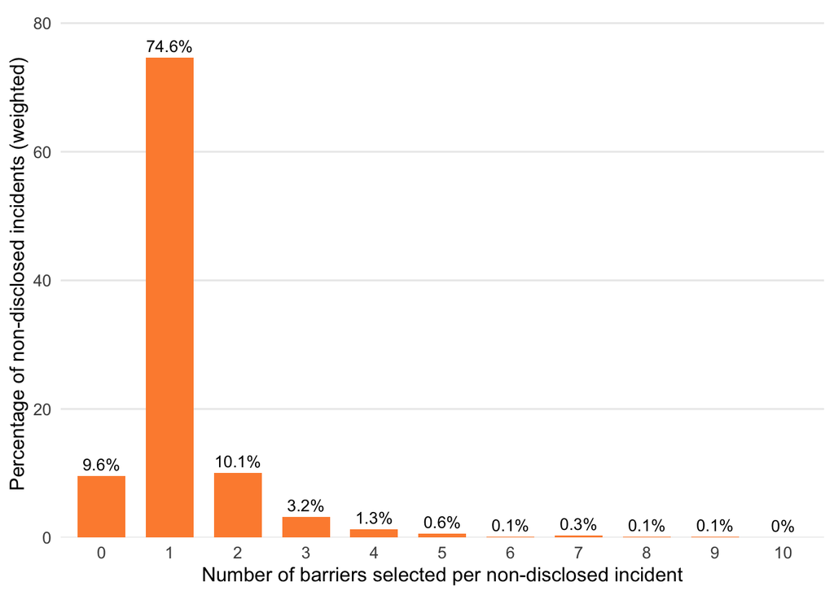

Figure 1: Distribution of number of barriers cited per non-disclosed incident

```r
# plot multiciplity
ggplot(n_barriers_summary, aes(x = factor(n_barriers), y = pct)) +
  geom_col(fill = "#FD8D3C", width = 0.7) +
  geom_text(aes(label = paste0(pct, "%")), vjust = -0.5, size = 3.5) +
  labs(
    x = "Number of barriers selected per non-disclosed incident",
    y = "Percentage of non-disclosed incidents (weighted)"
  ) +
  theme_minimal(base_size = 12) +
  theme(
    panel.grid.major.x = element_blank(),
    panel.grid.minor = element_blank(),
    axis.text = element_text(size = 10)
  ) +
  scale_y_continuous(expand = expansion(mult = c(0, 0.1)), limits = c(0, NA))

ggsave("Supp_Fig_barriers_distribution.png",
       width = 7,
       height = 5,
       dpi = 300
       )
```

## 3. Full Co-occurrence Matrix (Weighted)

We calculate pairwise co-occurrence frequencies for all barrier combinations using survey weights. Diagonal cells show individual barrier prevalence; off-diagonal cells show joint occurrence.

Matrix structure: - *Diagonal cells*: Individual barrier prevalence (what % of incidents cite this barrier) - *Off-diagonal cells*: Joint prevalence (what % of incidents cite BOTH barriers)

```r
# co-occurrence matrix
cooccurrence <- function(data, barriers) {

  # Binarise; catches any values > 1 from pivot_wider max aggregation
  data <- data %>%
    mutate(across(all_of(barriers), ~ as.integer(. >= 1)))

  n_total <- sum(data$wgt_scaled, na.rm = TRUE)

  M <- matrix(0, length(barriers), length(barriers),
              dimnames = list(barriers, barriers))
  for (i in seq_along(barriers)) {
    for (j in seq_along(barriers)) {
      b1 <- barriers[i]; b2 <- barriers[j]
      if (i == j) {
        M[i, j] <- 100 * sum(data$wgt_scaled[data[[b1]] == 1], na.rm = TRUE) / n_total
      } else {
        M[i, j] <- 100 * sum(data$wgt_scaled[data[[b1]] == 1 & data[[b2]] == 1], na.rm = TRUE) / n_total
      }
    }
  }
  M
}

cooc_matrix <- cooccurrence(bw_all, barrier_prefixes)

# top 5 pairs
upper_tri <- upper.tri(cooc_matrix)
pairs_df <- data.frame(
  barrier1 = rownames(cooc_matrix)[row(cooc_matrix)][upper_tri],
  barrier2 = colnames(cooc_matrix)[col(cooc_matrix)][upper_tri],
  pct      = cooc_matrix[upper_tri]
) %>%
  arrange(desc(pct)) %>%
  slice(1:5)

# labels
rownames(cooc_matrix) <- short_labels[rownames(cooc_matrix)]
colnames(cooc_matrix) <- short_labels[colnames(cooc_matrix)]

# diagonal
diagonal_vals <- sort(diag(cooc_matrix), decreasing = TRUE)
```

### Figure: Co-occurrence Heatmap

Here we visualize the complete 13×13 co-occurrence matrix showing all barrier relationships.

```r
# building concur
cooccur_df <- as.data.frame(as.table(cooc_matrix))
names(cooccur_df) <- c("Barrier1","Barrier2","Percent")
cooccur_df$Percent <- as.numeric(cooccur_df$Percent)

cooccur_df <- cooccur_df |>
  dplyr::mutate(
    is_diag     = Barrier1 == Barrier2,
    Percent_off = ifelse(is_diag, NA, Percent)
  )

max_off <- max(cooccur_df$Percent_off, na.rm = TRUE)
brks    <- seq(0, ceiling(max_off/10)*10, by = 10)
```

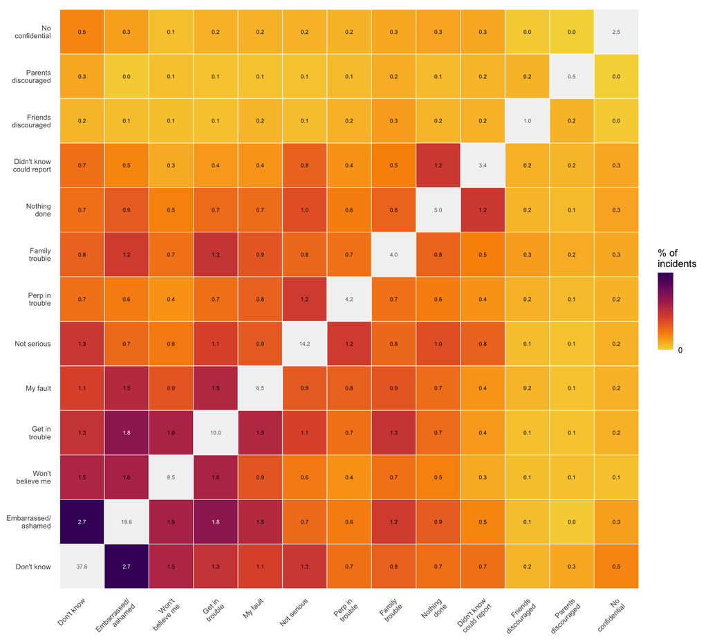

```r
cooccur_heatmap <- ggplot(cooccur_df, aes(x = Barrier2, y = Barrier1)) +
  geom_tile(aes(fill = Percent_off), color = "white", linewidth = 0.3) +
  geom_tile(
    data = subset(cooccur_df, is_diag),
    aes(x = Barrier2, y = Barrier1),
    fill = "grey95", color = "white", linewidth = 0.3
  ) +
  geom_text(
    data = subset(cooccur_df, !is_diag),
    aes(label = sprintf("%.1f", Percent),
        color = ifelse(Percent > 0.6 * max_off, "white", "black")),
    size = 2.2, show.legend = FALSE
  ) +
  geom_text(
    data = subset(cooccur_df, is_diag),
    aes(label = sprintf("%.1f", Percent)),
    size = 2.2, color = "grey40"
  ) +
  scale_color_identity() +
  scale_fill_viridis_c(
    option = "inferno",
    direction = -1,
    begin = 0.20,
    end   = 0.90,
    name = "% of\nincidents",
    limits = c(0, max_off),
    breaks = brks,
    na.value = "white"
  ) +
  coord_fixed() +
  theme_minimal(base_size = 11) +
  theme(
    axis.text.x = element_text(angle = 45, hjust = 1, vjust = 1, size = 8),
    axis.text.y = element_text(size = 8),
    axis.title  = element_blank(),
    legend.position = "right",
    panel.grid = element_blank()
  )

cooccur_heatmap
```

```r
ggsave("Fig_barrier_cooccurrence_weighted.pdf",
       plot = cooccur_heatmap,
       width = 11,
       height = 10,
       dpi = 300)
```

### Barriers summary tables

```r
# helpers for suppo tables
full_label <- function(x) {
  inv <- setNames(barrier_labels[names(short_labels)], unname(short_labels))
  out <- unname(inv[x])
  out[is.na(out)] <- x[is.na(out)]
  out
}

bcols <- function(df, cols) {
  miss <- setdiff(cols, names(df))
  if (length(miss)) df[miss] <- 0L
  df
}
```

### A) Multiplicity table (weighted)

Summarize the distribution of barrier counts for supplementary

```r
mult_table <- barrier_wide_all %>%
  bcols(barrier_prefixes) %>%
  mutate(
    across(
      all_of(barrier_prefixes),
      ~ as.integer(replace_na(. == 1 | . == "1", FALSE))
    ),
    n_barriers = rowSums(across(all_of(barrier_prefixes)), na.rm = TRUE),
    bin = case_when(
      .data$n_barriers == 0 ~ "0 (none selected)",
      .data$n_barriers == 1 ~ "1",
      .data$n_barriers %in% 2:3 ~ "2–3",
      .data$n_barriers >= 4 ~ "4+"
    )
  ) %>%
  count(.data$bin, wt = .data$wgt_scaled, name = "w") %>%
  mutate(`Weighted % of non-disclosed incidents` = round(100 * .data$w / sum(.data$w), 1)) %>%
  arrange(factor(.data$bin, levels = c("0 (none selected)", "1", "2–3", "4+"))) %>%
  select(`Number of barriers` = .data$bin, `Weighted % of non-disclosed incidents`)

mult_table %>%
  flextable() %>%
  align(align = "center", part = "all") %>%
  autofit()
```

| Number of barriers | Weighted % of non-disclosed incidents |
| --- | --- |
| 0 (none selected) | 9.6 |
| 1 | 74.6 |
| 2–3 | 13.3 |
| 4+ | 2.5 |

### B) Top co-occurring pairs (top 5)

Here we show the five most common barrier combinations.

```r
pairs_df <- as.data.frame(as.table(cooc_matrix), stringsAsFactors = FALSE)
names(pairs_df) <- c("b1_raw", "b2_raw", "Percent")

pairs_df <- pairs_df %>%
  filter(.data$b1_raw != .data$b2_raw) %>%
  mutate(
    r = match(.data$b1_raw, rownames(cooc_matrix)),
    c = match(.data$b2_raw, colnames(cooc_matrix))
  ) %>%
  filter(.data$r < .data$c) %>%
  arrange(desc(.data$Percent)) %>%
  mutate(
    `Barrier 1` = full_label(.data$b1_raw),
    `Barrier 2` = full_label(.data$b2_raw),
    `Percent`   = sprintf("%.1f", .data$Percent)
  ) %>%
  select(`Barrier 1`, `Barrier 2`, `Percent`) %>%
  slice(1:5)

pairs_df %>%
  flextable()
```

| Barrier 1 | Barrier 2 | Percent |
| --- | --- | --- |
| Did not know where to go/who to tell | Embarrassed/ashamed/too difficult | 2.7 |
| Embarrassed/ashamed/too difficult | Worried I would get in trouble | 1.8 |
| Embarrassed/ashamed/too difficult | Thought no one would believe me | 1.6 |
| Thought no one would believe me | Worried I would get in trouble | 1.6 |
| Did not know where to go/who to tell | Thought no one would believe me | 1.5 |